# 案例學習四

```r
needed <- c("jiebaR", "tidytext", "gutenbergr", "rvest", "wordcloud2")
install.packages(needed)
```

## Text as Data

- Text mining / Text analytics

## Pattern Matching using Regular Expressions (`regex` or `regexp`)

- Textual data is messy but meaningful. `regex` let us search for, clean, extract patterns from text to make it more meaningful.
- bit of language that can be used to describe a pattern within strings.

### Quick refresher: what is a string?

- A string is a sequence of characters that create a type of data.- Within R, strings belong to the class known as characters.
- Strings can consist of numbers, letters, spaces, and even some kinds of punctuation.
- `stringr`(part of `tidyverse`) a package in R that is designed to make working with strings easier by providing a consistent set of rules and conventions.
- We use the stringr package to manipulate strings within our dataset, often through the use of regular expressions.

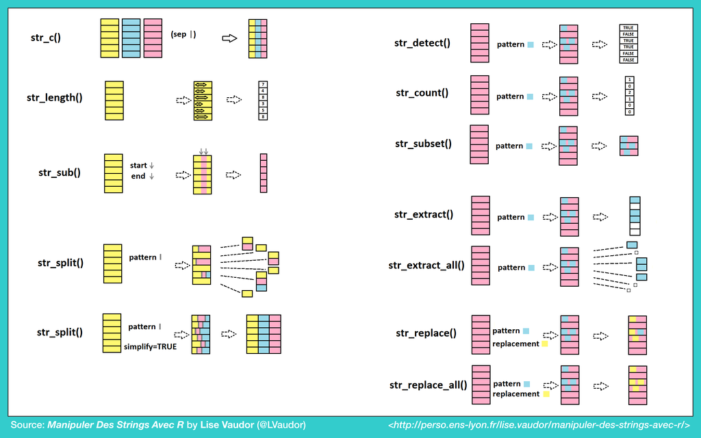

小抄

[又一張](https://www.rstudio.com/wp-content/uploads/2016/09/RegExCheatsheet.pdf)

### [Regular Expression in R](http://stat545.com/block022_regular-expression.html)

## EDA of Textual Data

### 中文處理的斷詞/分詞議題

- 字與詞
- 為何需要斷詞
- 斷詞系統

```r
library(tidyverse)
library(gutenbergr)
library(jiebaR)
library(jiebaRD)
library(wordcloud2)
```

- 使用「結巴」

```r
# 用 worker() 初始化斷詞引擎
seg <- worker()
seg
```

```
Worker Type:  Jieba Segment

Default Method  :  mix
Detect Encoding :  TRUE
Default Encoding:  UTF-8
Keep Symbols    :  FALSE
Output Path     :
Write File      :  TRUE
By Lines        :  FALSE
Max Word Length :  20
Max Read Lines  :  1e+05

Fixed Model Components:

$dict
[1] "/Library/Frameworks/R.framework/Versions/3.4/Resources/library/jiebaRD/dict/jieba.dict.utf8"

$user
[1] "/Library/Frameworks/R.framework/Versions/3.4/Resources/library/jiebaRD/dict/user.dict.utf8"

$hmm
[1] "/Library/Frameworks/R.framework/Versions/3.4/Resources/library/jiebaRD/dict/hmm_model.utf8"

$stop_word
NULL

$user_weight
[1] "max"

$timestamp
[1] 1509430738

$default $detect $encoding $symbol $output $write $lines $bylines can be reset.
```

```r
# 各種參數設定情參考  ?worker
```

- 斷詞簡單例子

```r
seg["台大最近的新聞怎麼這麼多"]
```

```
[1] "台大" "最近" "的"   "新聞" "怎麼" "這麼" "多"
```

```r
seg["據台大語言所小編謝舒凱表示，宅宅也是非常用功 der"]
```

```
 [1] "據"     "台大"   "語言所" "小編"   "謝舒凱" "表示"   "宅宅"
 [8] "也"     "是"     "非常"   "用功"   "der"
```

-設置停用詞表

```r
seg2 = worker(stop_word ="/Library/Frameworks/R.framework/Versions/3.4/Resources/library/jiebaRD/dict/stop_words.utf8")
seg2["據台大語言所小編謝舒凱表示，宅宅也是非常用功 der"]
```

[output not shown]

- 詞類標記

```r
tagger <- worker("tag")
tagger["台大最近的新聞怎麼這麼多"]
```

```
    ns      f     uj      n      r      r      m
"台大" "最近"   "的" "新聞" "怎麼" "這麼"   "多"
```

[詞類訊息](http://www.hankcs.com/nlp/corpus/several-revenue-segmentation-system-used-set-of-source-tagging.html)

- 讀檔斷詞

```r
outputfile <- seg["./你懂.txt"]
readLines(outputfile)
```

```
[1] "你 懂 熟女 姊姊 的 好嗎 社會 對 女人 很 殘酷 老 愛用 金銀銅鐵 比喻 女生 隨著 年華 老去 市場 價值 越來越低 的 現象 好像 20 歲 的 妹才 是 妹 30 歲 立馬 進入 花車 促銷 40 歲 架上 就 不 展示 了 但 各位 親愛 的 男士 你們 知道 其實 熟女 姊姊 才 是 真正 的 極品 嗎 當然 我 不 只是 說 片 教 你 的 那些 那些 熟女 的 誘惑 對 我們 而言 只是 基本 但 我們 真正 無敵 的 是 一顆 成熟 包容 的 心 有次 跟 朋友 吃飯 的 時候 席間 一個 25 歲 的 弟弟 滿面 愁容 他 說 小 他 兩歲 的 女友 對 他…
```

- 合併分词结果 ??

```r
out2 <- sapply(readLines(outputfile), function(x){paste(x, collapse = " ")})
writeLines(out2, "./nidong.txt")
```

```r
library(rvest)
pttMOVIE <- "https://www.ptt.cc/bbs/movie/index.html"
pttContent <- read_html(pttMOVIE)
```

[output not shown]

```r
seg[post_title] ## 不分行輸出
```

[output not shown]

```r
seg$bylines<-T
out3 <- seg[post_title] ## 分行輸出
out3
```

```
[[1]]
[1] "好雷"   "大佛"   "普拉斯" "腳色"   "縮影"   "有抑"   "無"

[[2]]
[1] "新聞" "華納" "宣布" "喪鐘" "電影" "企劃" "展開"

[[3]]
[1] "Re"       "討論"     "鋼"       "之"       "鍊金術師" "真人版"
[7] "預告"

[[4]]
[1] "請益"   "沒"     "看過"   "大佛"   "看得懂" "普拉斯" "嗎"

[[5]]
[1] "問片" "請問" "一部" "飛車" "追逐" "的"   "電影"

[[6]]
 [1] "新聞" "奪魂" "鋸"   "虐殺" "再現" "　"   "殺人" "魔"   "公布"
[10] "殺人" "法則"

[[7]]
 [1] "新聞"   "網瘋"   "傳江蕙" "有"     "客串"   "雷"     "神"
 [8] "3"      "無"     "違"     "和"     "真相"

[[8]]
[1] "Re"   "請益" "雷神" "三"   "關於" "索爾"

[[9]]
[1] "請益" "有雷" "索爾" "3"    "錘子"

[[10]]
[1] "Re"   "新聞" "華納" "宣布" "喪鐘" "電影" "企劃" "展開"

[[11]]
[1] "大爛雷" "大佛"   "普拉斯" "台灣"   "國片"   "的"     "末日"

[[12]]
 [1] "新聞"   "林育賢" "拍"     "翻滾"   "吧"     "系列"   "15"
 [8] "年"     "追逐"   "人生"   "奧運"

```

[output cut: 11 more lines]

```
[[16]]
[1] "好無雷" "殺人者" "的"     "記憶法"

[[17]]
[1] "討論" "關於" "諜報" "情報" "特務" "片"

[[18]]
[1] "請益" "對"   "電影" "翻譯" "字幕" "的"   "疑問"

[[19]]
[1] "公告"     "各式"     "疑難雜症" "FAQ"

[[20]]
 [1] "公告" "板規" "必"   "看"   "好"   "文"   "推薦" "惡"   "文"
[10] "檢舉"
```

```r
new_user_word(seg,'有抑無',"n")
```

```
[1] TRUE
```

- 最常出現的詞彙

```r
tem <- sort(table(unlist(seg[post_title])),decreasing = T)
tem <- as.data.frame.table(tem)
tem
```

[output not shown]

[output cut: 43 more lines]

- 文字雲 (`word cloud`) 用處不大，但是好玩。
  - `wordcloud2` provide traditional word cloud with HTML5.
  - 細節設定可以參考 [vignettes](https://cran.r-project.org/web/packages/wordcloud2/vignettes/wordcloud.html)
  - 還可以選自己的圖來當 mask ！

```r
library(wordcloud2)
## demoFreq is a data.frame including word and freq in each column.
wordcloud2(demoFreq, size = 1,shape = 'star')
```

[interactive chart not shown]

```r
#wordcloud2(demoFreq, size = 2, minRotation = -pi/6, maxRotation = -pi/6, rotateRatio = 1)
#wordcloud2(demoFreq, size = 2, minRotation = -pi/2, maxRotation = -pi/2)
wordcloud2(tem, size = 1,shape = 'star')
```

[interactive chart not shown]

```r
letterCloud(demoFreq, word = "R")
```

[interactive chart not shown]

```r
## Sys.setlocale("LC_CTYPE","eng")
## Sys.setlocale("LC_ALL", "Chinese (Traditional)_Taiwan.950")
```

### 案例練習一：自己的文本

讀入「妳懂.txt」這篇文章，做出詞頻表和文字雲。

```r
library(tidyverse)
library(gutenbergr)
library(jiebaR)
library(jiebaRD)
library(wordcloud2)
seq <- worker()
UKnow.seg <- seg["./你懂.txt"]
UKnow_df <- unlist(strsplit(readLines(UKnow.seg),split = " "))
UKnow.freq <- freq(UKnow_df)
colnames(UKnow.freq) <- c("word", "freq")
UKnow.freq <-UKnow.freq %>%
  arrange(desc(freq))
UKnow.freq
```

| word | freq |
| --- | --- |
| 的 | 50 |
| 我們 | 16 |
| 你 | 16 |
| 熟女 | 13 |
| 是 | 12 |
| 在 | 11 |
| 姊姊 | 10 |
| 男人 | 7 |
| 歲 | 7 |
| 如果 | 6 |

[output cut: 322 more lines]

```r
wordcloud2(UKnow.freq, size = 2)
```

[interactive chart not shown]

### 案例練習二：批踢踢的 NBA 版

po 文的標題中，最常出現的前 10 個詞？所有的音譯人民 (`nrf`) ?

```r
library(rvest)
pttMOVIE <- "https://www.ptt.cc/bbs/NBA/index.html"
pttContent <- read_html(pttMOVIE)
post_title <- pttContent %>%
  html_nodes(".title") %>%
  html_text()
post_title <- seq[post_title]
post_title_df <- unlist(post_title)
post_title.freq <- freq(post_title_df)
colnames(post_title.freq) <- c("word", "freq")
post_title.freq <-post_title.freq %>%
  arrange(desc(freq)) %>%
  head(10)
post_title.freq
```

|  | word | freq |
| --- | --- | --- |
| 1 | 情報 | 5 |
| 2 | 花邊 | 3 |
| 3 | 2017-18 | 2 |
| 4 | 我們 | 2 |
| 5 | 2017.10.25 | 1 |
| 6 | 171025 | 1 |
| 7 | Standings | 1 |
| 8 | NBA | 1 |
| 9 | 市場 | 1 |
| 10 | 安靜 | 1 |

```r
tagger <- worker("tag")
nr <- tagger[post_title]
nr
```

```
           n          eng          eng            v           zg
      "花邊"       "Wall"       "Ball"         "是"         "個"
          nr           uj            n            r            d
      "安靜"         "的"       "孩子"       "我們"         "都"
           v            v            a            n          eng
        "想"         "打"         "好"       "花邊"      "Rubio"
         eng          eng            n           nr            v
      "Fxck"     "Cancer"       "花邊"       "沃頓"       "沒有"
          nr            r           zg            v           mq
    "蘭德爾"       "我們"         "贏"       "不了"       "這場"
          vn            n           zg           ng            v
      "比賽"       "情報"         "糗"         "爺"       "請吃"
           x            v            n            n            m
      "雞排"         "沒"       "問題"       "情報"    "2017-18"
           a            n            n            a            n
      "自由"       "球員"       "市場"       "異動"     "整理表"
           x            m            n            x          eng
         "9"         "26"       "公告"       "板規"         "v6"
           x            n            m            v           nz
         "2"       "情報"    "2017-18"       "例行"         "賽"
           n            m            m            n          eng
      "賽程"         "10"      "18-31"       "情報"        "NBA"
         eng            m            n            t            v
 "Standings"     "171025"       "情報"       "今日"       "排名"
         eng
"2017.10.25"
```

### 案例練習三：魯迅的吶喊

> https//www.gutenberg.org 是個開放的文本庫

```r
luxun <- gutenberg_download(27166)
str(luxun)
```

```r
luxun.seg <- seg[luxun$text]
luxun.seg
```

- 建立詞頻表，更改變數名稱

```r
luxun_df <- unlist(luxun.seg)
luxun.freq <- freq(luxun_df)
colnames(luxun.freq) <- c("word", "freq")
luxun_df
```

```r
luxun.freq %>%
  arrange(desc(freq)) %>%
  head(20)
```

|  | word | freq |
| --- | --- | --- |
| 1 | 的 | 2609 |
| 2 | 了 | 1423 |
| 3 | 他 | 825 |
| 4 | 是 | 606 |
| 5 | 我 | 599 |
| 6 | 也 | 597 |
| 7 | 在 | 466 |
| 8 | ︰ | 345 |
| 9 | 說 | 328 |
| 10 | 這 | 323 |

[output cut: 10 more lines]

- 詞類標記

```r
pos.tagger <- worker("tag")
luxun.pos <- pos.tagger[luxun$text]
```

```r
fd <- data.frame(luxun.pos, names(luxun.pos))
colnames(fd) <- c("WORD", "POS")
```

```r
Word_POS_Freq <- fd %>%
  group_by(WORD, POS) %>%
  summarise(Frequency = n())
```

```r
Word_POS_Freq %>%
  filter(POS == "r")%>%
  arrange(desc(Frequency)) %>%
  head(100)
```

| WORD | POS | Frequency |
| --- | --- | --- |
| 他 | r | 825 |
| 我 | r | 599 |
| 你 | r | 178 |
| 他們 | r | 162 |
| 什麼 | r | 145 |
| 那 | r | 127 |
| 自己 | r | 127 |
| 我們 | r | 90 |
| 有些 | r | 73 |
| 這樣 | r | 56 |

[output cut: 90 more lines]

- 取出所有標記為 `r` (代名詞) 的前 100 個詞。

協同解題平台：https://paper.dropbox.com/doc/Case-Study-Collaborative-Way-64YWTbYXKEviSqG8yppsc

# 參考

- http://qinwenfeng.com/jiebaR/
- https://cran.r-project.org/web/packages/wordcloud2/vignettes/wordcloud.html
- http://tidytextmining.com/tidytext.html
- http://www.gastonsanchez.com/Handling_and_Processing_Strings_in_R.pdf